# Section 0: Contrast matrices

# Section 1: Analysis of gene expression measured with Microarrays

Lets starts by

- importing the data set *microarrays* with the function `read.csv()`

## Section 1B: Student T-test

Boxplot of the data:

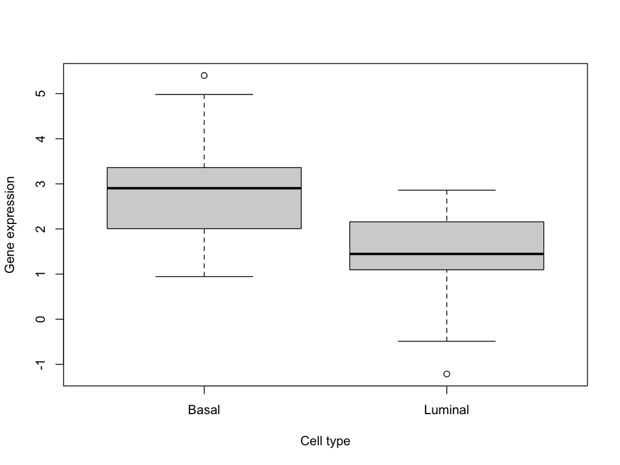

```r
microarrays = read.csv("data/03-microarrays.csv",row.names=1)
boxplot(expression~celltype,data=microarrays,col="light gray",
        ylab = "Gene expression", xlab = "Cell type")
```

As a linear model:

```r
fit = lm(expression~celltype-1,data=microarrays)
summary(fit)
```

```
##
## Call:
## lm(formula = expression ~ celltype - 1, data = microarrays)
##
## Residuals:
##      Min       1Q   Median       3Q      Max
## -2.64401 -0.58586  0.01473  0.65051  2.47771
##
## Coefficients:
##                 Estimate Std. Error t value Pr(>|t|)
## celltypeBasal     2.9239     0.1684  17.361  < 2e-16 ***
## celltypeLuminal   1.4293     0.1475   9.687 8.47e-15 ***
## ---
## Signif. codes:  0 '***' 0.001 '**' 0.01 '*' 0.05 '.' 0.1 ' ' 1
##
## Residual standard error: 0.9675 on 74 degrees of freedom
## Multiple R-squared:  0.8423, Adjusted R-squared:  0.838
## F-statistic: 197.6 on 2 and 74 DF,  p-value: < 2.2e-16
```

```r
#
fit = lm(expression~celltype,data=microarrays)
summary(fit)
```

```
##
## Call:
## lm(formula = expression ~ celltype, data = microarrays)
##
## Residuals:
##      Min       1Q   Median       3Q      Max
## -2.64401 -0.58586  0.01473  0.65051  2.47771
##
## Coefficients:
##                 Estimate Std. Error t value Pr(>|t|)
## (Intercept)       2.9239     0.1684  17.361  < 2e-16 ***
## celltypeLuminal  -1.4946     0.2239  -6.675 3.94e-09 ***
## ---
## Signif. codes:  0 '***' 0.001 '**' 0.01 '*' 0.05 '.' 0.1 ' ' 1
##
## Residual standard error: 0.9675 on 74 degrees of freedom
## Multiple R-squared:  0.3758, Adjusted R-squared:  0.3674
## F-statistic: 44.56 on 1 and 74 DF,  p-value: 3.941e-09
```

relationship with a Student’s T-test:

```r
Basal = microarrays$expression[microarrays$celltype=="Basal"]
Luminal = microarrays$expression[microarrays$celltype=="Luminal"]
t.test(Basal,Luminal,var.equal=TRUE)
```

```
##
##  Two Sample t-test
##
## data:  Basal and Luminal
## t = 6.6751, df = 74, p-value = 3.941e-09
## alternative hypothesis: true difference in means is not equal to 0
## 95 percent confidence interval:
##  1.048457 1.940748
## sample estimates:
## mean of x mean of y
##  2.923908  1.429305
```

## Section 1C: One-way ANOVA

Regression model:

```r
# model 1
summary(lm(expression~mousetype-1,data=microarrays))
```

```
##
## Call:
## lm(formula = expression ~ mousetype - 1, data = microarrays)
##
## Residuals:
##      Min       1Q   Median       3Q      Max
## -2.91070 -0.78893 -0.09926  0.80387  2.98027
##
## Coefficients:
##                    Estimate Std. Error t value Pr(>|t|)
## mousetypeLactating   2.1051     0.2302   9.146 9.90e-14 ***
## mousetypePregnant    2.4213     0.2392  10.123 1.51e-15 ***
## mousetypeVirgin      1.6907     0.2441   6.926 1.43e-09 ***
## ---
## Signif. codes:  0 '***' 0.001 '**' 0.01 '*' 0.05 '.' 0.1 ' ' 1
##
## Residual standard error: 1.196 on 73 degrees of freedom
## Multiple R-squared:  0.7623, Adjusted R-squared:  0.7525
## F-statistic: 78.03 on 3 and 73 DF,  p-value: < 2.2e-16
```

```r
# model 2
summary(lm(expression~mousetype,data=microarrays))
```

```
##
## Call:
## lm(formula = expression ~ mousetype, data = microarrays)
##
## Residuals:
##      Min       1Q   Median       3Q      Max
## -2.91070 -0.78893 -0.09926  0.80387  2.98027
##
## Coefficients:
##                   Estimate Std. Error t value Pr(>|t|)
## (Intercept)         2.1051     0.2302   9.146  9.9e-14 ***
## mousetypePregnant   0.3162     0.3319   0.953    0.344
## mousetypeVirgin    -0.4144     0.3355  -1.235    0.221
## ---
## Signif. codes:  0 '***' 0.001 '**' 0.01 '*' 0.05 '.' 0.1 ' ' 1
##
## Residual standard error: 1.196 on 73 degrees of freedom
## Multiple R-squared:  0.05917,    Adjusted R-squared:  0.0334
## F-statistic: 2.296 on 2 and 73 DF,  p-value: 0.1079
```

Relationship with Fisher’s one-way ANOVA (functions `aov()`)

```r
# model 1
summary(aov(expression~mousetype-1,data=microarrays))
```

```
##           Df Sum Sq Mean Sq F value Pr(>F)
## mousetype  3  334.8  111.61   78.03 <2e-16 ***
## Residuals 73  104.4    1.43
## ---
## Signif. codes:  0 '***' 0.001 '**' 0.01 '*' 0.05 '.' 0.1 ' ' 1
```

```r
# model 2
summary(aov(expression~mousetype,data=microarrays))
```

```
##             Df Sum Sq Mean Sq F value Pr(>F)
## mousetype    2   6.57   3.283   2.296  0.108
## Residuals   73 104.41   1.430
```

## Section 1D: Two-way ANOVA

Regression model:

```r
# without interactions
summary(lm(expression~mousetype+celltype,data=microarrays))
```

```
##
## Call:
## lm(formula = expression ~ mousetype + celltype, data = microarrays)
##
## Residuals:
##      Min       1Q   Median       3Q      Max
## -2.28721 -0.47310  0.00495  0.50585  2.14941
##
## Coefficients:
##                   Estimate Std. Error t value Pr(>|t|)
## (Intercept)         2.9294     0.2171  13.494  < 2e-16 ***
## mousetypePregnant   0.3228     0.2603   1.240    0.219
## mousetypeVirgin    -0.3732     0.2632  -1.418    0.161
## celltypeLuminal    -1.4837     0.2171  -6.834 2.24e-09 ***
## ---
## Signif. codes:  0 '***' 0.001 '**' 0.01 '*' 0.05 '.' 0.1 ' ' 1
##
## Residual standard error: 0.9379 on 72 degrees of freedom
## Multiple R-squared:  0.4293, Adjusted R-squared:  0.4055
## F-statistic: 18.05 on 3 and 72 DF,  p-value: 7.754e-09
```

```r
anova(lm(expression~mousetype+celltype,data=microarrays))
```

```
## Analysis of Variance Table
##
## Response: expression
##           Df Sum Sq Mean Sq F value    Pr(>F)
## mousetype  2  6.567   3.283  3.7327   0.02868 *
## celltype   1 41.077  41.077 46.6975 2.238e-09 ***
## Residuals 72 63.333   0.880
## ---
## Signif. codes:  0 '***' 0.001 '**' 0.01 '*' 0.05 '.' 0.1 ' ' 1
```

```r
# with interactions
summary(lm(expression~mousetype*celltype,data=microarrays))
```

```
##
## Call:
## lm(formula = expression ~ mousetype * celltype, data = microarrays)
##
## Residuals:
##     Min      1Q  Median      3Q     Max
## -2.2424 -0.5921  0.1583  0.6059  2.1799
##
## Coefficients:
##                                   Estimate Std. Error t value Pr(>|t|)
## (Intercept)                         2.7427     0.2719  10.088 2.77e-15 ***
## mousetypePregnant                   0.6562     0.3931   1.669  0.09956 .
## mousetypeVirgin                    -0.1237     0.4033  -0.307  0.75991
## celltypeLuminal                    -1.1476     0.3648  -3.146  0.00243 **
## mousetypePregnant:celltypeLuminal  -0.5980     0.5264  -1.136  0.25980
## mousetypeVirgin:celltypeLuminal    -0.4437     0.5340  -0.831  0.40885
## ---
## Signif. codes:  0 '***' 0.001 '**' 0.01 '*' 0.05 '.' 0.1 ' ' 1
##
## Residual standard error: 0.9418 on 70 degrees of freedom
## Multiple R-squared:  0.4405, Adjusted R-squared:  0.4005
## F-statistic: 11.02 on 5 and 70 DF,  p-value: 7.529e-08
```

```r
anova(lm(expression~mousetype*celltype,data=microarrays))
```

```
## Analysis of Variance Table
##
## Response: expression
##                    Df Sum Sq Mean Sq F value    Pr(>F)
## mousetype           2  6.567   3.283  3.7017   0.02964 *
## celltype            1 41.077  41.077 46.3093 2.825e-09 ***
## mousetype:celltype  2  1.243   0.622  0.7007   0.49969
## Residuals          70 62.090   0.887
## ---
## Signif. codes:  0 '***' 0.001 '**' 0.01 '*' 0.05 '.' 0.1 ' ' 1
```

Relationship with the two-way ANOVA (functions `aov()`)

```r
# without interactions
summary(aov(expression~mousetype+celltype,data=microarrays))
```

```
##             Df Sum Sq Mean Sq F value   Pr(>F)
## mousetype    2   6.57    3.28   3.733   0.0287 *
## celltype     1  41.08   41.08  46.698 2.24e-09 ***
## Residuals   72  63.33    0.88
## ---
## Signif. codes:  0 '***' 0.001 '**' 0.01 '*' 0.05 '.' 0.1 ' ' 1
```

```r
# with interactions
summary(aov(expression~mousetype*celltype,data=microarrays))
```

```
##                    Df Sum Sq Mean Sq F value   Pr(>F)
## mousetype           2   6.57    3.28   3.702   0.0296 *
## celltype            1  41.08   41.08  46.309 2.83e-09 ***
## mousetype:celltype  2   1.24    0.62   0.701   0.4997
## Residuals          70  62.09    0.89
## ---
## Signif. codes:  0 '***' 0.001 '**' 0.01 '*' 0.05 '.' 0.1 ' ' 1
```

## Section 1E: Linear model

Estimate the regression coefficients of the model with interation by hand

```r
# prepare
Y = microarrays$expression
X = model.matrix(~mousetype*celltype,data=microarrays)
# estimate
Beta.hat = solve(t(X)%*%X)%*%t(X)%*%Y
```

```r
# prepare
E  = rnorm(nrow(X),mean=0,sd=.25)
Y  = X%*%Beta.hat + E
# estimate
summary(lm(Y~microarrays$mousetype*microarrays$celltype))
```

```
##
## Call:
## lm(formula = Y ~ microarrays$mousetype * microarrays$celltype)
##
## Residuals:
##      Min       1Q   Median       3Q      Max
## -0.68793 -0.14359  0.01462  0.14929  0.68515
##
## Coefficients:
##                                                           Estimate
## (Intercept)                                                2.60256
## microarrays$mousetypePregnant                              0.60249
## microarrays$mousetypeVirgin                               -0.04967
## microarrays$celltypeLuminal                               -1.00399
## microarrays$mousetypePregnant:microarrays$celltypeLuminal -0.48079
## microarrays$mousetypeVirgin:microarrays$celltypeLuminal   -0.52321
##                                                           Std. Error
## (Intercept)                                                  0.07250
## microarrays$mousetypePregnant                                0.10484
## microarrays$mousetypeVirgin                                  0.10754
## microarrays$celltypeLuminal                                  0.09727
## microarrays$mousetypePregnant:microarrays$celltypeLuminal    0.14036
## microarrays$mousetypeVirgin:microarrays$celltypeLuminal      0.14239
##                                                           t value Pr(>|t|)
## (Intercept)                                                35.897  < 2e-16
## microarrays$mousetypePregnant                               5.747 2.18e-07
## microarrays$mousetypeVirgin                                -0.462 0.645622
## microarrays$celltypeLuminal                               -10.322 1.05e-15
## microarrays$mousetypePregnant:microarrays$celltypeLuminal  -3.425 0.001031
## microarrays$mousetypeVirgin:microarrays$celltypeLuminal    -3.675 0.000463
##
## (Intercept)                                               ***
## microarrays$mousetypePregnant                             ***
## microarrays$mousetypeVirgin
## microarrays$celltypeLuminal                               ***
## microarrays$mousetypePregnant:microarrays$celltypeLuminal **
## microarrays$mousetypeVirgin:microarrays$celltypeLuminal   ***
## ---
## Signif. codes:  0 '***' 0.001 '**' 0.01 '*' 0.05 '.' 0.1 ' ' 1
##
## Residual standard error: 0.2512 on 70 degrees of freedom
## Multiple R-squared:  0.9008, Adjusted R-squared:  0.8938
## F-statistic: 127.2 on 5 and 70 DF,  p-value: < 2.2e-16
```

# Section 3: Large Scale Hypothesis testing: FDR

When we are doing thousands of tests for differential expression, the overall significance level of a test is very difficult to control. Let’s see why: First, we simulate 40,000 genes not differentially expressed (with a mean of zero). We assume that we have 10 replicates of this experiment:

```r
N <- 40000
R <- 10
X <- matrix(rnorm(N* R, 0, 1), nrow=N)
```

Now we assume that we run a t-test under the null hypothesis that the mean is zero for each of these genes, that is each row in the matrix:

```r
t.test(X[1,])$p.value
```

```
## [1] 0.5901051
```

```r
pvals <- apply(X, 1, function(y) t.test(y)$p.value)
```

Because we have generated this data with mean zero, we know that none of these genes are differentially expressed, so we would like to be able to not reject any of the hypothesis. However, if you choose a significance level of 0.05 we get

```r
sum(pvals<0.05)
```

```
## [1] 1972
```

Too many rejections!!! In fact, if we look at the distributions of the p-values obtained we get:

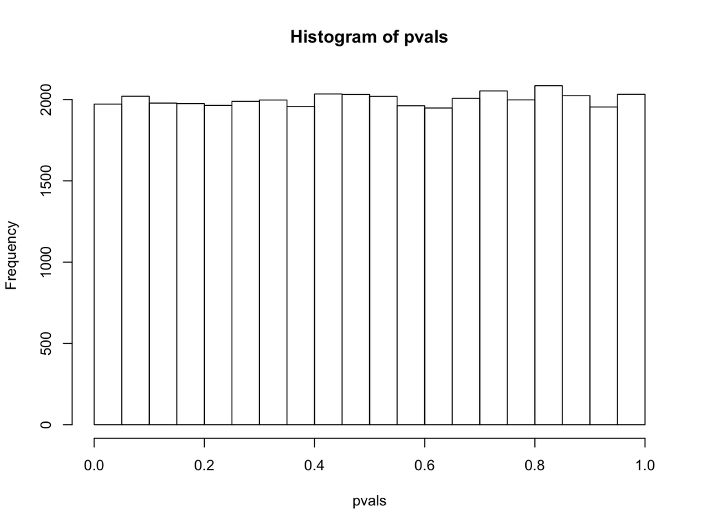

```r
hist(pvals)
```

That is, if the null hypothesis is true, the p-values will follow a uniform distribution. This is the key to all methods that aim to control the proportion of false positives amongs the genes that we call differentially expressed. Let’s add 1000 genes to our set that are really differentially expressed (mean of 1):

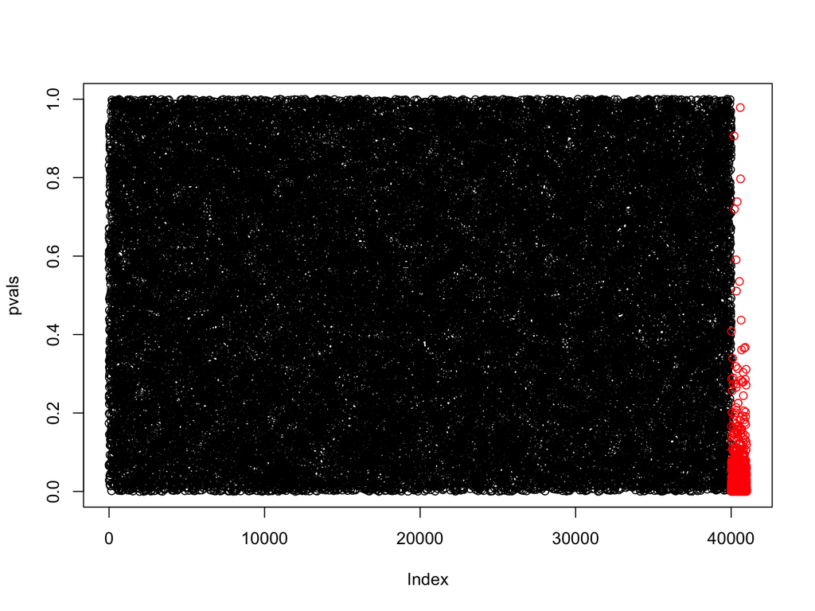

```r
df <- 1000
Y <- matrix(rnorm(df* R, 1, 1), nrow=df)
Z <- rbind(X, Y)
pvals <- apply(Z, 1, function(y) t.test(y)$p.value)
#
plot(pvals,col=rep(1:2,c(40000,1000)))
```

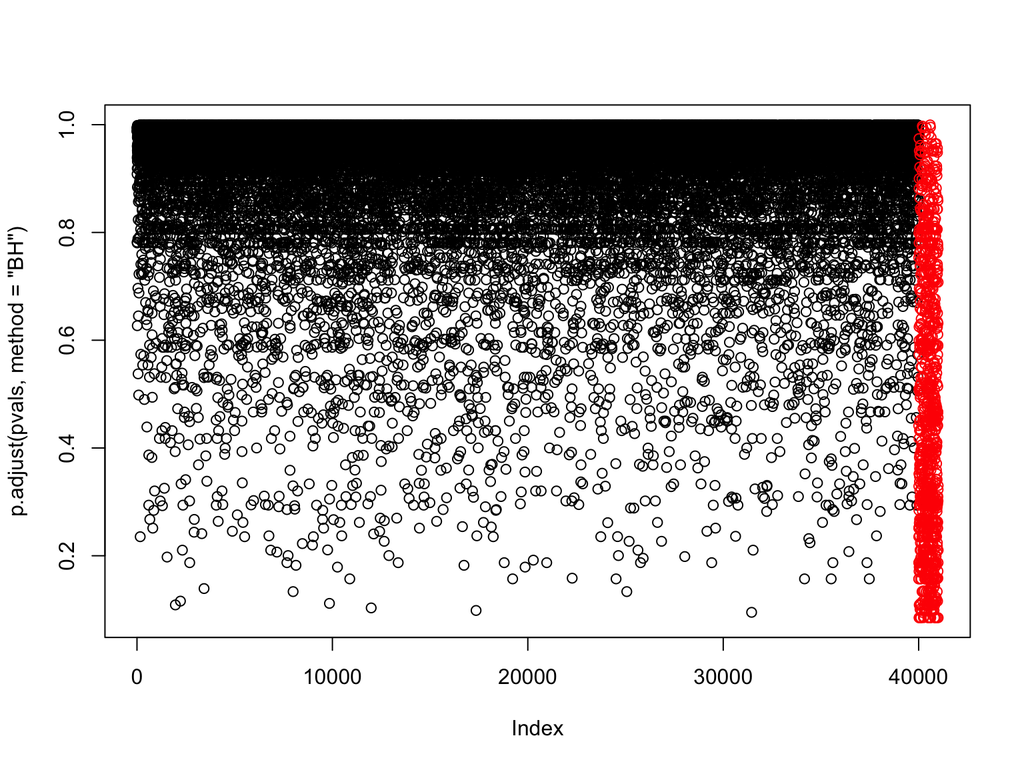

```r
plot(p.adjust(pvals, method="BH"),col=rep(1:2,c(40000,1000)))
```

```r
#
tapply(p.adjust(pvals, method="BH")<0.05,rep(1:2,c(40000,1000)),mean)
```

```
## 1 2
## 0 0
```

Let’s look at the distribution of p-values now:

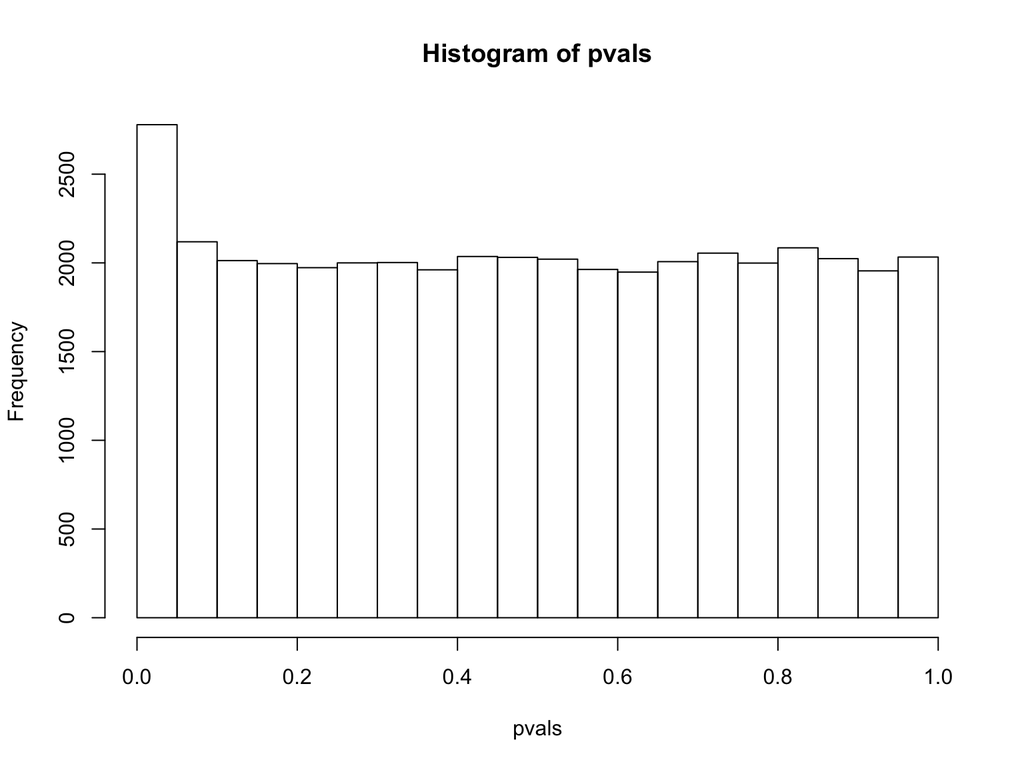

```r
hist(pvals)
```

What would be the number of false positives now? How many would we expect if we reject p-values samller than our significance level, 0.05?

```r
exp.sig<- (nrow(Z))*0.05
obs.sig <- sum(pvals<0.05)
FDR <- exp.sig / obs.sig
FDR
```

```
## [1] 0.7376754
```

We can compare this with the Benjamini-Hochberg method:

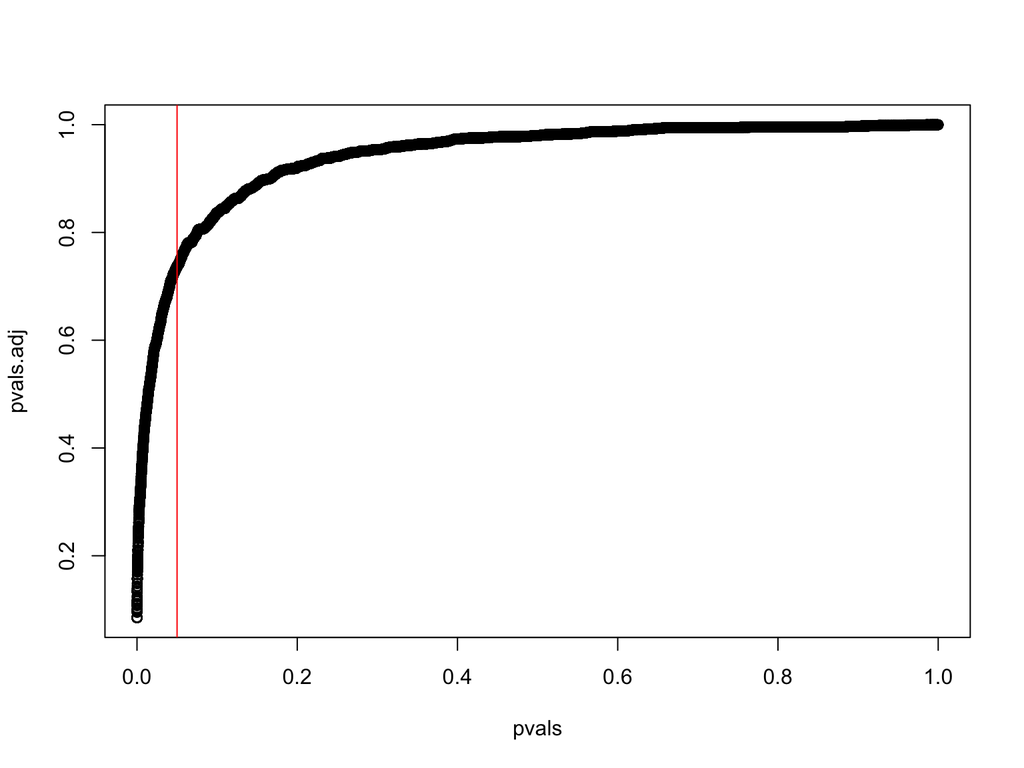

```r
pvals.adj <- p.adjust(pvals, method="BH")
plot(pvals, pvals.adj)
abline(v=0.05, col=2)
```